# lab03_rosynek

## Lab 3 - Decision Boundaries

Name: Paige Rosynek

Date: 9.28.2022

### Introduction

The purpose of this lab is to gain familiarity with decision boundaries and how they help classify data, as well as how to effectively evaluate a model. The data set used throughout this lab is the Iris dataset. Each part of this lab followed a similar procedure: plot two features (and color according to class), plot a decision boundary, classify points based on the decision boundary, and the calculate the accuracy of the predicted labels. In Part 1 of the lab, only two features are plotted and 3 different decision boundaries are given. The accuracy of the model for each of the decision boundaries was calculated and compared in order to observe the relationship between how well a decision boundary separates data and its accuracy. In Part 2 of the lab, two different sets of two features is plotted and compared to show the difference in how a model performs on data that is easily separated and data that is not. Lastly, Part 3 of the lab performs an experimental setup with test-train splitting of the data and how it effects the accuracy of a model. We will be observing how evaluating data on the training set, testing set, and validation set influences how well the model can predict labels given data, as well as how to interpret accuracy in each of these situations. In general, the experiments performed in this lab further exemplify the importance of an experimental setup when training model as well as the general psteps required for training a classification model when given a data set.

#### Problem 1:

**1. Just by looking at your plot, which of the three decision boundaries does the best job of separating the two classes of points?**

```
It can be observed from the plot in 1D that boundary line 2 (red line) does the best job separating the two classes. The decision boundary has the equation: $x_2 = 0.75x_1 - 0.9$ and does a good job separating the classes such that the majority of points for each class are on opposite sides of the line.
```

**2. Which of the three decision boundaries gave the more accurate predictions?**

```
The decision boundary that had the highest prediction accuracy was decision boundary 2 (red line), which is also the line that best separates the classes. It had an accuracy of 99.33%.
```

**3. How does the accuracy metric seem to relate to the ability of the decision boundary to separate the classes?**

```
The decision boundary's ability to separate the classes is directly related to the accuracy of the predictions that the decision boundary produces. Therefore, the better a decision boundary can separate the classes, the more accurate the model predictions will be for that boundary line.
```

### Problem 2:

**1. For which pair of features are the classes more easily separated?**

```
For the veriscolor and virgnica dataset, it can be observed from the plots in 2c, that petal width and petal length are more easily separated than sepal width/length. The scatter plot for sepal width versus sepal height shows the different categories of flowers mixed together; and it has no evident pattern in which the features can be easily separated. However, the petal width versus height plot shows points in which points from the same class are near each other making it easily separable.
```

**2. Just by looking at your plots, for which pair of features does the decision boundary do a better job of separating the classes?**

```
The decision boundary best separates the different classes for the features petal width and petal height. For the most part, all the points on each side of the line are the same class.
```

**3. Which decision boundary gives the most accurate predictions?**

```
The decision boundary that produced the most accurate predictions was the decision boundary for the petal width v. petal length plot, with the equation: $x_2 = -0.7x_1 + 5$. It had an accuracy of about 95%.
```

**4. How does the choice of features seem to impact the ability to make accurate predictions?**

```
The accuracy of predicitions is better if the features are easily separated by a decision boundary line.
```

### Problem 3:

**1. Compare the accuracies you calculated from the training and testing data sets. Predictions for which data set were evaluated as more accurate? Which accuracy score do you think is a more realistic representation of the performance of the model?**

```
The accuracy calculated for the training set was 100% while the accuracy calculated for the testing set was about 85.71%, thus the predictions evaluated on the training set were calculated to be "more accurate". However, it is misleading to believe that the accuracy for the model evaluated on the training set will be 100% accurate. The reason that the accuracy for the model evaluated on the training set was 100% is because the model was both trained and evaluated on the same exact set of data, thus the model wasn't really evaluated at all since it had seen all of the data before and used that same data to build the model. Therefore, it is more realistic to represent the accuracy of the model with the accuracy of the model that was evaluated on the testing set. The model evaluated on the testing set actually shows a representation of the ability of the model to predict unseen data.
```

**2. Look at the scatter plot of the validation data points. Will the model make errors in predicting the labels? Why?**

```
The model will make errors predicting the labels because the decision boundary for the validation data separates only most of the classes. Since the decision boundary doesn't separate the validation points perfectly, it is to be expected that the model will mislabel some of the data.
```

**3. Look at the scatter plots of the training and testing data points. Which data set is more representative of the validation data set? Which data set will demonstrate errors similar to the validation set?**

```
The testing set is more representative of the validation data because the graphs are similarly separated and because the validation and testing data both contain data unseen by the model. The testing set will have error similar to the validation set because the data within these sets has not been seen by the model during training, which better tests the model's ability to predict a label for a new data point not within the dataset.
```

**4. Compare the accuracies you calculated from the training and testing data sets to the validation data set. Which accuracy calculation is more representative of the accuracy for the validation data set?**

```
The calculated accuracy for the testing set was 85.71% and the training set had an accuracy of 100%. The testing accuracy is more representative of the accuracy for the validation set because the data in the testing and validation sets is unseen data to the model that was trained on the training set. The training set had an accuracy of 100% because the model was trained on the data in the training set, so by evaluating the model with the training set we are giving the model everything it already knows so it doesn't make any mistakes. By evaluating the model with data it hasn't seen, it better simulates how accurate the model would be when used in a real-world setting.
```

**5. Explain why training and evaluating a model on the same data set can be deceptive.**

```
As mentioned above, training and evaluating a model on the same data set can be deceptive because although you might find the accuracy of your model to be 100%, it will not perform this well when given an observation not in the training set. The model forms its predictions because it found patterns in the training set. Then if you test the model on how well it can predict the same data it was trained on, the model will have an accuracy of 100% since it "knows" the data already. Thus, training and testing a model on the same data gives a false sense of confidence in the model because the accuracy appears to be really good when in reality the model's accuracy is much less for data it has never seen before.
```

**6. Explain how dividing data into training and testing sets with no repeated points resolves some of the problems associated with training and evaluating a model on the same data set.**

```
Dividing a dataset into training and testing sets without replacement solves some of the similar issues of testing a model on the same data it was trained on. By not training a model on redundant data the possibility of overfitting the model is reduced because the model won't be able to recognize or "memorize" certain data. Having redundant data in the testing and training sets will also make your model accuracy deceiving because the model will correctly predict any data it has seen previously, like the data from the training set.
```

**7. Name 3 potential ramifications for publishing a model that was trained and characterized using the same data set.**

```
One problem would be the model's poor ability to generalize. A model trained and evaluated on the same data set is overfit (has a high variance) and specific to the dataset, thus it cannot accurately predict new, never seen data making it a bad model to publish. Another possible consequence is that if the data used to train and test the model were not scaled it is possible that one feature will have a higher importance than another feature due to differences in the value ranges for the features. Overall, the biggest issue with training and evaluating a model on the same data is overfitting. By training and testing on the same data, the model learns patterns that are very specific to that data and is therefore overfit. An overfit model does not generalize well to new data points and will thus perform poorly in the real-world.
```

#### 1. Decision Boundaries & Evaluation of Model Predictions

Part A

```python
import pandas as pd
import matplotlib.pyplot as plt
import seaborn as sns
import numpy as np

setosa_df = pd.read_csv('../Data/setosa_data.csv')
```

Part B

```python
setosa_df.head()
```

|  | label | sepal_length (cm) | sepal_width (cm) |
| --- | --- | --- | --- |
| 0 | not setosa | 5.1 | 3.5 |
| 1 | not setosa | 4.9 | 3.0 |
| 2 | not setosa | 4.7 | 3.2 |
| 3 | not setosa | 4.6 | 3.1 |
| 4 | not setosa | 5.0 | 3.6 |

Part C

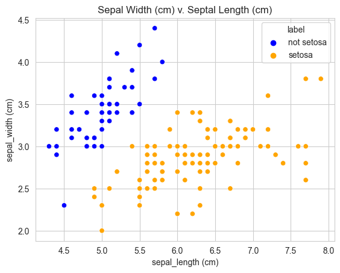

```python
colors = {'setosa' : 'orange', 'not setosa' : 'blue'}

sns.scatterplot(data=setosa_df, x='sepal_length (cm)', y='sepal_width (cm)', hue='label', palette=colors)
plt.title('Sepal Width (cm) v. Septal Length (cm)')
plt.show()
```

Part D

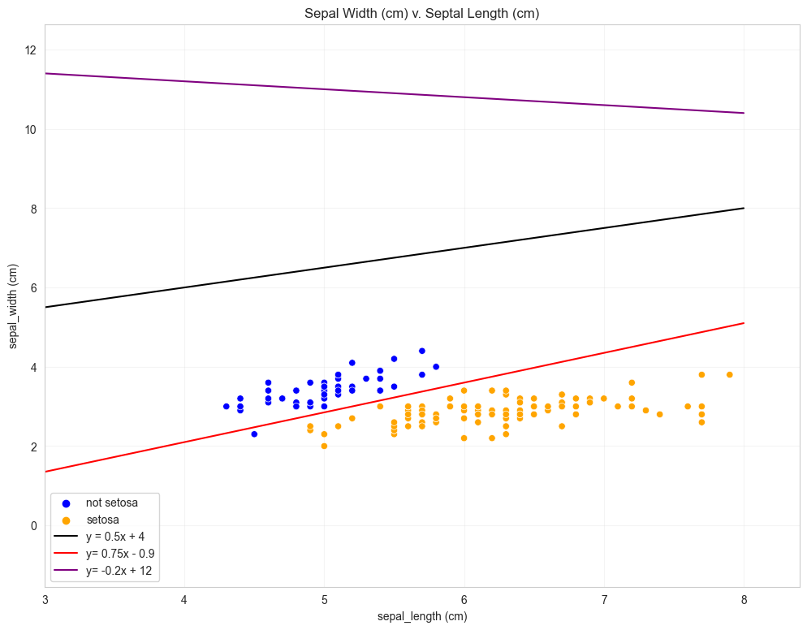

```python
x = np.linspace(0,8,1000)
colors = {'setosa' : 'orange', 'not setosa' : 'blue'}

y1 = 0.5*x + 4
y2 = 0.75*x - 0.9
y3 = -0.2*x + 12

plt.figure().set_size_inches(12,9)

sns.scatterplot(data=setosa_df, x='sepal_length (cm)', y='sepal_width (cm)', hue='label', palette=colors)
plt.title('Sepal Width (cm) v. Septal Length (cm)')

plt.plot(x, y1, c='black', label='y = 0.5x + 4')
plt.plot(x, y2, c='red', label='y= 0.75x - 0.9')
plt.plot(x, y3, c='purple', label='y= -0.2x + 12')

plt.xlim(3)
plt.legend()
plt.grid(alpha=0.2)
plt.show()
```

e.

- Decision Boundary 1 (black) : $x_1 - 2x_2 + 8 = 0$
- Decision Boundary 2 (red) : $-0.75x_1 + x_2 + 0.9 = 0$
- Decision Boundary 3 (purple) : $0.2x_1 + x_2 - 12 = 0$

f.

```python
from decision_boundaries import linear_decision_boundary_classifier

dec_bound_vec1 = np.array([1.0, -2.0, 8.0])
dec_bound_vec2 = np.array([-0.75, 1.0, 0.9])
dec_bound_vec3 = np.array([0.2, 1.0, -12])

features = setosa_df[['sepal_length (cm)', 'sepal_width (cm)']].values
true_labels = setosa_df['label'].values

pred_labels1 = linear_decision_boundary_classifier(dec_bound_vec1, features, true_labels, features)
pred_labels2 = linear_decision_boundary_classifier(dec_bound_vec2, features, true_labels, features)
pred_labels3 = linear_decision_boundary_classifier(dec_bound_vec3, features, true_labels, features)

print('boundary 1 : x1 - 2x2 + 8 = 0\n', pred_labels1)
print('boundary 2 : -0.75x1 + x2 + 0.9 = 0\n', pred_labels2)
print('boundary 3 : 0.2x1 + x2 - 12 = 0\n', pred_labels3)
```

```
boundary 1 : x1 - 2x2 + 8 = 0
 ['setosa' 'setosa' 'setosa' 'setosa' 'setosa' 'setosa' 'setosa' 'setosa'
 'setosa' 'setosa' 'setosa' 'setosa' 'setosa' 'setosa' 'setosa' 'setosa'
 'setosa' 'setosa' 'setosa' 'setosa' 'setosa' 'setosa' 'setosa' 'setosa'
 'setosa' 'setosa' 'setosa' 'setosa' 'setosa' 'setosa' 'setosa' 'setosa'
 'setosa' 'setosa' 'setosa' 'setosa' 'setosa' 'setosa' 'setosa' 'setosa'
 'setosa' 'setosa' 'setosa' 'setosa' 'setosa' 'setosa' 'setosa' 'setosa'
 'setosa' 'setosa' 'setosa' 'setosa' 'setosa' 'setosa' 'setosa' 'setosa'
 'setosa' 'setosa' 'setosa' 'setosa' 'setosa' 'setosa' 'setosa' 'setosa'
 'setosa' 'setosa' 'setosa' 'setosa' 'setosa' 'setosa' 'setosa' 'setosa'
 'setosa' 'setosa' 'setosa' 'setosa' 'setosa' 'setosa' 'setosa' 'setosa'
 'setosa' 'setosa' 'setosa' 'setosa' 'setosa' 'setosa' 'setosa' 'setosa'
 'setosa' 'setosa' 'setosa' 'setosa' 'setosa' 'setosa' 'setosa' 'setosa'
 'setosa' 'setosa' 'setosa' 'setosa' 'setosa' 'setosa' 'setosa' 'setosa'
 'setosa' 'setosa' 'setosa' 'setosa' 'setosa' 'setosa' 'setosa' 'setosa'
 'setosa' 'setosa' 'setosa' 'setosa' 'setosa' 'setosa' 'setosa' 'setosa'
 'setosa' 'setosa' 'setosa' 'setosa' 'setosa' 'setosa' 'setosa' 'setosa'
 'setosa' 'setosa' 'setosa' 'setosa' 'setosa' 'setosa' 'setosa' 'setosa'
 'setosa' 'setosa' 'setosa' 'setosa' 'setosa' 'setosa' 'setosa' 'setosa'
 'setosa' 'setosa' 'setosa' 'setosa' 'setosa' 'setosa']
boundary 2 : -0.75x1 + x2 + 0.9 = 0
 ['not setosa' 'not setosa' 'not setosa' 'not setosa' 'not setosa'
 'not setosa' 'not setosa' 'not setosa' 'not setosa' 'not setosa'
 'not setosa' 'not setosa' 'not setosa' 'not setosa' 'not setosa'
 'not setosa' 'not setosa' 'not setosa' 'not setosa' 'not setosa'
 'not setosa' 'not setosa' 'not setosa' 'not setosa' 'not setosa'
 'not setosa' 'not setosa' 'not setosa' 'not setosa' 'not setosa'
 'not setosa' 'not setosa' 'not setosa' 'not setosa' 'not setosa'
 'not setosa' 'not setosa' 'not setosa' 'not setosa' 'not setosa'
 'not setosa' 'setosa' 'not setosa' 'not setosa' 'not setosa' 'not setosa'
 'not setosa' 'not setosa' 'not setosa' 'not setosa' 'setosa' 'setosa'
 'setosa' 'setosa' 'setosa' 'setosa' 'setosa' 'setosa' 'setosa' 'setosa'
 'setosa' 'setosa' 'setosa' 'setosa' 'setosa' 'setosa' 'setosa' 'setosa'
 'setosa' 'setosa' 'setosa' 'setosa' 'setosa' 'setosa' 'setosa' 'setosa'
 'setosa' 'setosa' 'setosa' 'setosa' 'setosa' 'setosa' 'setosa' 'setosa'
 'setosa' 'setosa' 'setosa' 'setosa' 'setosa' 'setosa' 'setosa' 'setosa'
 'setosa' 'setosa' 'setosa' 'setosa' 'setosa' 'setosa' 'setosa' 'setosa'
 'setosa' 'setosa' 'setosa' 'setosa' 'setosa' 'setosa' 'setosa' 'setosa'
 'setosa' 'setosa' 'setosa' 'setosa' 'setosa' 'setosa' 'setosa' 'setosa'
 'setosa' 'setosa' 'setosa' 'setosa' 'setosa' 'setosa' 'setosa' 'setosa'
```

[output cut: 9 more lines]

```
 'setosa' 'setosa' 'setosa' 'setosa' 'setosa' 'setosa' 'setosa' 'setosa'
 'setosa' 'setosa' 'setosa' 'setosa' 'setosa' 'setosa' 'setosa' 'setosa'
 'setosa' 'setosa' 'setosa' 'setosa' 'setosa' 'setosa' 'setosa' 'setosa'
 'setosa' 'setosa' 'setosa' 'setosa' 'setosa' 'setosa' 'setosa' 'setosa'
 'setosa' 'setosa' 'setosa' 'setosa' 'setosa' 'setosa' 'setosa' 'setosa'
 'setosa' 'setosa' 'setosa' 'setosa' 'setosa' 'setosa' 'setosa' 'setosa'
 'setosa' 'setosa' 'setosa' 'setosa' 'setosa' 'setosa' 'setosa' 'setosa'
 'setosa' 'setosa' 'setosa' 'setosa' 'setosa' 'setosa' 'setosa' 'setosa'
 'setosa' 'setosa' 'setosa' 'setosa' 'setosa' 'setosa' 'setosa' 'setosa'
 'setosa' 'setosa' 'setosa' 'setosa' 'setosa' 'setosa' 'setosa' 'setosa'
 'setosa' 'setosa' 'setosa' 'setosa' 'setosa' 'setosa' 'setosa' 'setosa'
 'setosa' 'setosa' 'setosa' 'setosa' 'setosa' 'setosa' 'setosa' 'setosa'
 'setosa' 'setosa' 'setosa' 'setosa' 'setosa' 'setosa' 'setosa' 'setosa'
 'setosa' 'setosa' 'setosa' 'setosa' 'setosa' 'setosa' 'setosa' 'setosa'
 'setosa' 'setosa' 'setosa' 'setosa' 'setosa' 'setosa']
```

```
c:\Users\rosynekp\OneDrive - Milwaukee School of Engineering\Desktop\cs3400\labs\lab03\lab03-rosynekp\Code\decision_boundaries.py:27: FutureWarning: Unlike other reduction functions (e.g. `skew`, `kurtosis`), the default behavior of `mode` typically preserves the axis it acts along. In SciPy 1.11.0,…
  neg_label = mode(training_labels[neg_mask])[0]
c:\Users\rosynekp\OneDrive - Milwaukee School of Engineering\Desktop\cs3400\labs\lab03\lab03-rosynekp\Code\decision_boundaries.py:31: FutureWarning: Unlike other reduction functions (e.g. `skew`, `kurtosis`), the default behavior of `mode` typically preserves the axis it acts along. In SciPy 1.11.0,…
  pos_label = mode(training_labels[pos_mask])[0]
```

g.

```python
from sklearn.metrics import accuracy_score

acc1 = accuracy_score(true_labels, pred_labels1)
acc2 = accuracy_score(true_labels, pred_labels2)
acc3 = accuracy_score(true_labels, pred_labels3)

print('accuracy for boundary 1 = {}'.format(acc1))
print('accuracy for boundary 2 = {}'.format(acc2))
print('accuracy for boundary 3 = {}'.format(acc3))
```

```
accuracy for boundary 1 = 0.6666666666666666
accuracy for boundary 2 = 0.9933333333333333
accuracy for boundary 3 = 0.6666666666666666
```

### 2. Predictive Power of Features

a.

```python
vv_data = pd.read_csv('../Data/versicolor_virginica_data.csv')
```

b.

```python
vv_data.head()
```

|  | label | sepal_length (cm) | sepal_width (cm) | petal_length (cm) | petal_width (cm) |
| --- | --- | --- | --- | --- | --- |
| 0 | versicolor | 7.0 | 3.2 | 4.7 | 1.4 |
| 1 | versicolor | 6.4 | 3.2 | 4.5 | 1.5 |
| 2 | versicolor | 6.9 | 3.1 | 4.9 | 1.5 |
| 3 | versicolor | 5.5 | 2.3 | 4.0 | 1.3 |
| 4 | versicolor | 6.5 | 2.8 | 4.6 | 1.5 |

c.

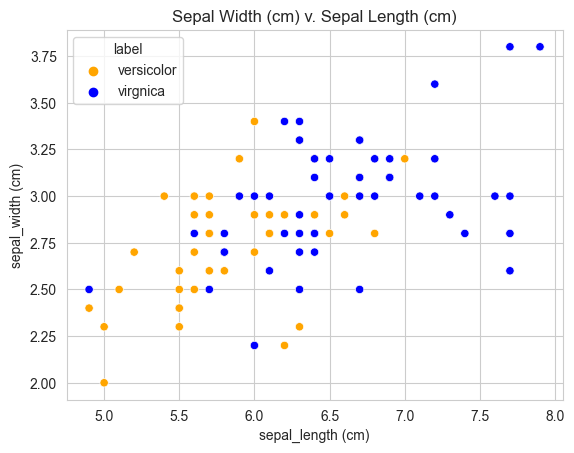

```python
colors = {'versicolor' : 'orange', 'virgnica' : 'blue'}
sns.scatterplot(data=vv_data, x='sepal_length (cm)', y='sepal_width (cm)', hue='label', palette=colors)
plt.title('Sepal Width (cm) v. Sepal Length (cm)')
```

d.

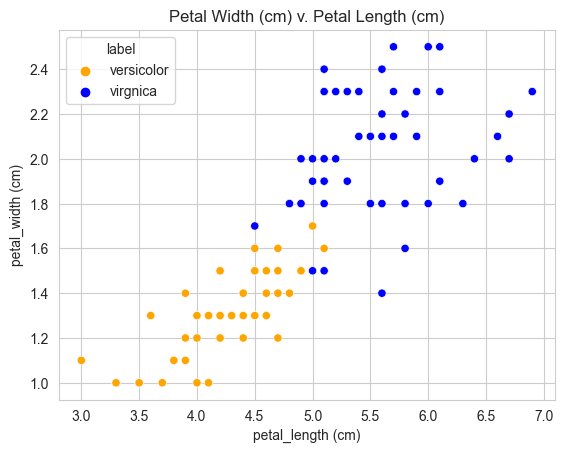

```python
colors = {'versicolor' : 'orange', 'virgnica' : 'blue'}
sns.scatterplot(data=vv_data, x='petal_length (cm)', y='petal_width (cm)', hue='label', palette=colors)
plt.title('Petal Width (cm) v. Petal Length (cm)')
```

e.

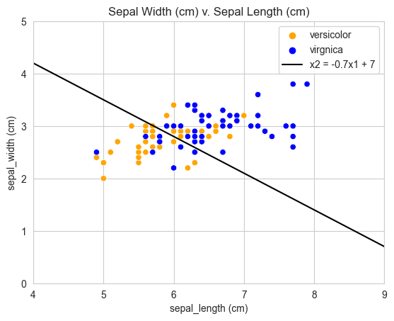

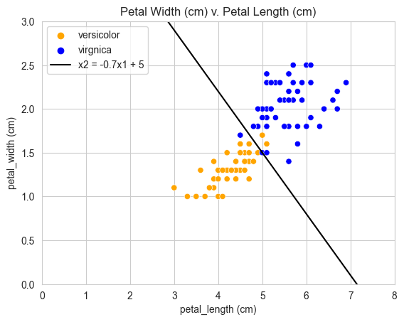

```python
x = np.linspace(0,10,100)
colors = {'versicolor' : 'orange', 'virgnica' : 'blue'}

#---boundary1---
sns.scatterplot(data=vv_data, x='sepal_length (cm)', y='sepal_width (cm)', hue='label', palette=colors)
plt.title('Sepal Width (cm) v. Sepal Length (cm)')

y1 = -0.7*x + 7
plt.plot(x, y1, c='black', label='x2 = -0.7x1 + 7')
plt.legend()
plt.xlim(4,9)
plt.ylim(0,5)
plt.show()

#---boundary2---
sns.scatterplot(data=vv_data, x='petal_length (cm)', y='petal_width (cm)', hue='label', palette=colors)
plt.title('Petal Width (cm) v. Petal Length (cm)')

y2 = -0.7*x + 5
plt.plot(x, y2, c='black', label='x2 = -0.7x1 + 5')
plt.legend()
plt.xlim(0,8)
plt.ylim(0,3)
plt.show()
```

f.

- Decision boundary $x_2 = -0.7x_1 + 7$

  standard form : $0.7x_1 + x_2 - 7 = 0$
- Decision boundary $x_2 = -0.7x_1 + 5$

  standard form : $0.7x_1 + x_2 - 5 = 0$

g.

```python
db_vec1 = np.array([0.7, 1.0, -7.0])
db_vec2 = np.array([0.7, 1.0, -5.0])

features1 = vv_data[['sepal_length (cm)', 'sepal_width (cm)']].values
features2 = vv_data[['petal_length (cm)', 'petal_width (cm)']].values
true_labels = vv_data['label'].values

pred1 = linear_decision_boundary_classifier(db_vec1, features1, true_labels, features1)
pred2 = linear_decision_boundary_classifier(db_vec2, features2, true_labels, features2)

print('boundary 1 : x2 = -0.7x1 + 7\n', pred1)
print('boundary 2 : -x2 = -0.7x + 5\n', pred2)
```

```
boundary 1 : x2 = -0.7x1 + 7
 ['virgnica' 'virgnica' 'virgnica' 'versicolor' 'virgnica' 'versicolor'
 'virgnica' 'versicolor' 'virgnica' 'versicolor' 'versicolor' 'virgnica'
 'versicolor' 'virgnica' 'versicolor' 'virgnica' 'versicolor' 'versicolor'
 'versicolor' 'versicolor' 'virgnica' 'virgnica' 'versicolor' 'virgnica'
 'virgnica' 'virgnica' 'virgnica' 'virgnica' 'virgnica' 'versicolor'
 'versicolor' 'versicolor' 'versicolor' 'versicolor' 'versicolor'
 'virgnica' 'virgnica' 'versicolor' 'versicolor' 'versicolor' 'versicolor'
 'virgnica' 'versicolor' 'versicolor' 'versicolor' 'versicolor'
 'versicolor' 'virgnica' 'versicolor' 'versicolor' 'virgnica' 'versicolor'
 'virgnica' 'virgnica' 'virgnica' 'virgnica' 'versicolor' 'virgnica'
 'virgnica' 'virgnica' 'virgnica' 'virgnica' 'virgnica' 'versicolor'
 'versicolor' 'virgnica' 'virgnica' 'virgnica' 'virgnica' 'versicolor'
 'virgnica' 'versicolor' 'virgnica' 'virgnica' 'virgnica' 'virgnica'
 'virgnica' 'virgnica' 'virgnica' 'virgnica' 'virgnica' 'virgnica'
 'virgnica' 'virgnica' 'versicolor' 'virgnica' 'virgnica' 'virgnica'
 'virgnica' 'virgnica' 'virgnica' 'virgnica' 'versicolor' 'virgnica'
 'virgnica' 'virgnica' 'versicolor' 'virgnica' 'virgnica' 'virgnica']
boundary 2 : -x2 = -0.7x + 5
 ['versicolor' 'versicolor' 'versicolor' 'versicolor' 'versicolor'
 'versicolor' 'versicolor' 'versicolor' 'versicolor' 'versicolor'
 'versicolor' 'versicolor' 'versicolor' 'versicolor' 'versicolor'
 'versicolor' 'versicolor' 'versicolor' 'versicolor' 'versicolor'
 'virgnica' 'versicolor' 'versicolor' 'versicolor' 'versicolor'
 'versicolor' 'versicolor' 'virgnica' 'versicolor' 'versicolor'
 'versicolor' 'versicolor' 'versicolor' 'virgnica' 'versicolor'
 'versicolor' 'versicolor' 'versicolor' 'versicolor' 'versicolor'
 'versicolor' 'versicolor' 'versicolor' 'versicolor' 'versicolor'
 'versicolor' 'versicolor' 'versicolor' 'versicolor' 'versicolor'
 'virgnica' 'virgnica' 'virgnica' 'virgnica' 'virgnica' 'virgnica'
 'versicolor' 'virgnica' 'virgnica' 'virgnica' 'virgnica' 'virgnica'
 'virgnica' 'virgnica' 'virgnica' 'virgnica' 'virgnica' 'virgnica'
 'virgnica' 'versicolor' 'virgnica' 'virgnica' 'virgnica' 'virgnica'
 'virgnica' 'virgnica' 'virgnica' 'virgnica' 'virgnica' 'virgnica'
 'virgnica' 'virgnica' 'virgnica' 'virgnica' 'virgnica' 'virgnica'
 'virgnica' 'virgnica' 'virgnica' 'virgnica' 'virgnica' 'virgnica'
 'virgnica' 'virgnica' 'virgnica' 'virgnica' 'virgnica' 'virgnica'
 'virgnica' 'virgnica']
```

```
c:\Users\rosynekp\OneDrive - Milwaukee School of Engineering\Desktop\cs3400\labs\lab03\lab03-rosynekp\Code\decision_boundaries.py:27: FutureWarning: Unlike other reduction functions (e.g. `skew`, `kurtosis`), the default behavior of `mode` typically preserves the axis it acts along. In SciPy 1.11.0,…
  neg_label = mode(training_labels[neg_mask])[0]
c:\Users\rosynekp\OneDrive - Milwaukee School of Engineering\Desktop\cs3400\labs\lab03\lab03-rosynekp\Code\decision_boundaries.py:31: FutureWarning: Unlike other reduction functions (e.g. `skew`, `kurtosis`), the default behavior of `mode` typically preserves the axis it acts along. In SciPy 1.11.0,…
  pos_label = mode(training_labels[pos_mask])[0]
```

h.

```python
acc1 = accuracy_score(true_labels, pred1)
acc2 = accuracy_score(true_labels, pred2)

print('accuracy for boundary 1 = {}'.format(acc1))
print('accuracy for boundary 2 = {}'.format(acc2))
```

```
accuracy for boundary 1 = 0.7
accuracy for boundary 2 = 0.95
```

### 3. Experimental Setup with Test-Train Splitting

a.

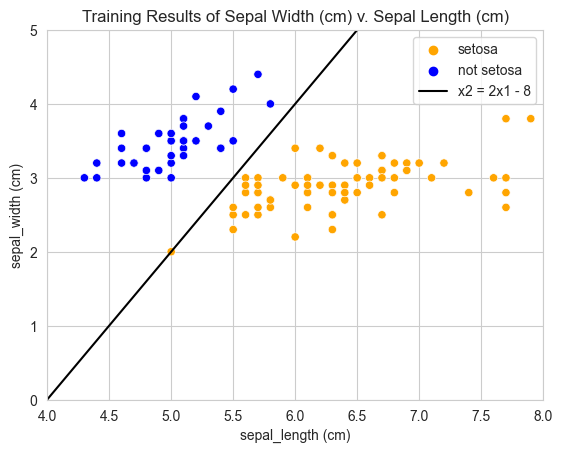

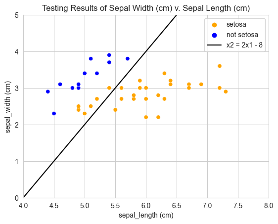

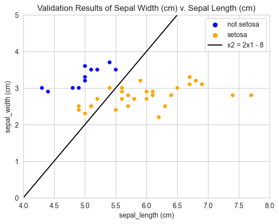

```python
setosa_train = pd.read_csv('../Data/setosa_training.csv')
setosa_test = pd.read_csv('../Data/setosa_testing.csv')
setosa_val = pd.read_csv('../Data/setosa_validation.csv')

x = np.linspace(0,10,100)
y = 2*x - 8
colors = {'setosa' : 'orange', 'not setosa' : 'blue'}

sns.scatterplot(data=setosa_train, x='sepal_length (cm)', y='sepal_width (cm)', hue='label', palette=colors)
plt.title('Training Results of Sepal Width (cm) v. Sepal Length (cm)')
plt.plot(x, y, c='black', label='x2 = 2x1 - 8')
plt.xlim(4,8)
plt.ylim(0,5)
plt.legend()
plt.show()

sns.scatterplot(data=setosa_test, x='sepal_length (cm)', y='sepal_width (cm)', hue='label', palette=colors)
plt.title('Testing Results of Sepal Width (cm) v. Sepal Length (cm)')
plt.plot(x, y, c='black', label='x2 = 2x1 - 8')
plt.xlim(4,8)
plt.ylim(0,5)
plt.legend()
plt.show()

sns.scatterplot(data=setosa_val, x='sepal_length (cm)', y='sepal_width (cm)', hue='label', palette=colors)
plt.title('Validation Results of Sepal Width (cm) v. Sepal Length (cm)')
plt.plot(x, y, c='black', label='x2 = 2x1 - 8')
plt.xlim(4,8)
plt.ylim(0,5)
plt.legend()
plt.show()
```

b.

```python
db_vec = np.array([-2.0, 1.0, 8.0])

feat_train = setosa_train[['sepal_length (cm)', 'sepal_width (cm)']]
feat_test = setosa_test[['sepal_length (cm)', 'sepal_width (cm)']]
feat_val = setosa_val[['sepal_length (cm)', 'sepal_width (cm)']]

true_train = setosa_train['label'].values
true_test = setosa_test['label'].values
true_val = setosa_val['label'].values

# train : training set  eval : training set
pred1 = linear_decision_boundary_classifier(db_vec, feat_train, true_train, feat_train)

# train : training set  eval : testing set
pred2 = linear_decision_boundary_classifier(db_vec, feat_train, true_train, feat_test)

# train : training set  eval : validation set
pred3 = linear_decision_boundary_classifier(db_vec, feat_train, true_train, feat_val)


acc1 = accuracy_score(true_train, pred1)
acc2 = accuracy_score(true_test, pred2)
acc3 = accuracy_score(true_val, pred3)

print('boundary line for all plots : x2 = 2x1 - 8')
print('evaluate on training set :\n\taccuracy = {}'.format(acc1))
print('evaluate on testing set :\n\taccuracy = {}'.format(acc2))
print('evaluate on validation set :\n\taccuracy = {}'.format(acc3))
```

```
boundary line for all plots : x2 = 2x1 - 8
evaluate on training set :
	accuracy = 1.0
evaluate on testing set :
	accuracy = 0.8571428571428571
evaluate on validation set :
	accuracy = 0.8636363636363636
```

```
c:\Users\rosynekp\OneDrive - Milwaukee School of Engineering\Desktop\cs3400\labs\lab03\lab03-rosynekp\Code\decision_boundaries.py:27: FutureWarning: Unlike other reduction functions (e.g. `skew`, `kurtosis`), the default behavior of `mode` typically preserves the axis it acts along. In SciPy 1.11.0,…
  neg_label = mode(training_labels[neg_mask])[0]
c:\Users\rosynekp\OneDrive - Milwaukee School of Engineering\Desktop\cs3400\labs\lab03\lab03-rosynekp\Code\decision_boundaries.py:31: FutureWarning: Unlike other reduction functions (e.g. `skew`, `kurtosis`), the default behavior of `mode` typically preserves the axis it acts along. In SciPy 1.11.0,…
  pos_label = mode(training_labels[pos_mask])[0]
```